# Homework Answers

Mingming Xiang

2023-12-04

# Homework-2023.09.11

## Question 1

Use knitr to produce at least 3 examples. For each example, texts should mix with figures and/or tables. Better to have mathematical formulas.

### Example 1

`iris` 是一个数据集，分别给出了3种鸢尾花（每种各50朵）萼片的长度和宽度，花瓣的长度和宽度（以厘米为单位）测量值。

```r
# 直接输出数据
test <- head(iris)
test
```

```
##   Sepal.Length Sepal.Width Petal.Length Petal.Width Species
## 1          5.1         3.5          1.4         0.2  setosa
## 2          4.9         3.0          1.4         0.2  setosa
## 3          4.7         3.2          1.3         0.2  setosa
## 4          4.6         3.1          1.5         0.2  setosa
## 5          5.0         3.6          1.4         0.2  setosa
## 6          5.4         3.9          1.7         0.4  setosa
```

```r
# 展示为表格
knitr::kable(test)
```

| Sepal.Length | Sepal.Width | Petal.Length | Petal.Width | Species |
| --- | --- | --- | --- | --- |
| 5.1 | 3.5 | 1.4 | 0.2 | setosa |
| 4.9 | 3.0 | 1.4 | 0.2 | setosa |
| 4.7 | 3.2 | 1.3 | 0.2 | setosa |
| 4.6 | 3.1 | 1.5 | 0.2 | setosa |
| 5.0 | 3.6 | 1.4 | 0.2 | setosa |
| 5.4 | 3.9 | 1.7 | 0.4 | setosa |

```r
# 得到Latex形式的表格
xtable::xtable(test)
```

```
## % latex table generated in R 4.3.2 by xtable 1.8-4 package
## % Sun Dec 10 02:43:35 2023
## \begin{table}[ht]
## \centering
## \begin{tabular}{rrrrrl}
##   \hline
##  & Sepal.Length & Sepal.Width & Petal.Length & Petal.Width & Species \\
##   \hline
## 1 & 5.10 & 3.50 & 1.40 & 0.20 & setosa \\
##   2 & 4.90 & 3.00 & 1.40 & 0.20 & setosa \\
##   3 & 4.70 & 3.20 & 1.30 & 0.20 & setosa \\
##   4 & 4.60 & 3.10 & 1.50 & 0.20 & setosa \\
##   5 & 5.00 & 3.60 & 1.40 & 0.20 & setosa \\
##   6 & 5.40 & 3.90 & 1.70 & 0.40 & setosa \\
##    \hline
## \end{tabular}
## \end{table}
```

### Example 2

使用`ggplot2`进行数据可视化，例如可用`geom_point()`函数绘制散点图：

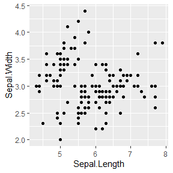

```r
library(ggplot2)
ggplot(iris, aes(x=Sepal.Length, y=Sepal.Width)) + geom_point()
```

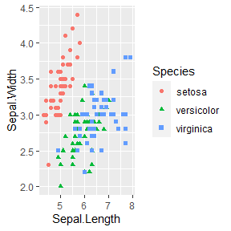

```r
# 将鸢尾花的类型映射给点的颜色和形状
fig_all <- ggplot(iris, aes(x=Sepal.Length, y=Sepal.Width, colour=Species, shape=Species)) + geom_point()
fig_all
```

### Example 3

考虑对类别为`setosa`的数据进行线性回归建模，并绘制回归模型拟合线。线性回归模型为：
$$Y=\beta_0+\beta_1X$$

我们首先筛选数据：

```r
setosa <- iris[iris$Species == "setosa",]
```

可以使用`stst_smooth()`函数并设置`method=lm`向散点图中加入拟合线：

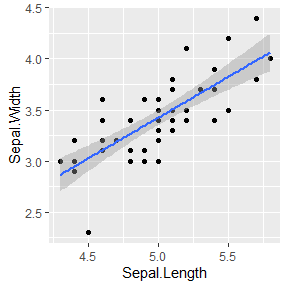

```r
fig_setosa <- ggplot(setosa, aes(x=Sepal.Length, y=Sepal.Width))
fig_setosa + geom_point() + stat_smooth(method = lm)
```

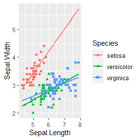

```r
# 同时绘制3种类型数据的拟合线
fig_all + geom_smooth(method = lm, fullrange = TRUE, se = FALSE)
```

# Homework-2023.09.18

## Question 1

利用逆变换法复现函数`sample`的部分功能:`replace = TRUE`

### Answer

```r
mySample <- function(x,n){
  m <- length(x)
  p <- rep(1,m)/m
  cp <- cumsum(p)

  u <- runif(n)
  r <- x[findInterval(u,cp)+1]
  return(r)
}

x <- mySample(1:6,2000) #test
table(x)
```

```
## x
##   1   2   3   4   5   6
## 332 352 332 338 322 324
```

## Question 2

The standard Laplace distribution has density $f(x)=\frac{1}{2}e^{-|x|}$, $x\in\mathbb R$. Use the inverse transform method to generate a random sample of size 1000 from this distribution. Use one of the methods shown in this chapter to compare the generated sample to the target distribution.

### Answer

Note that
$$\begin{aligned}
F(x)& =\int_{-\infty}^xf(u)\mathrm{d}u \\
&=\begin{cases}&\frac12\exp\left(x\right)&\mathrm{if~}x<0\\\\&1-\frac12\exp\left(-x\right)&\mathrm{if~}x\geq0&\end{cases}
\\
&=0.5\left[1+\mathrm{sgn}(x)\left(1-\exp(-|x|)\right)\right],
\end{aligned}$$
then
$$F^{-1}(p)=\begin{cases}&\ln(2p)&\mathrm{if~}p<0.5\\\\&-\ln(2(1-p))&\mathrm{if~}p\geq0.5&\end{cases}$$

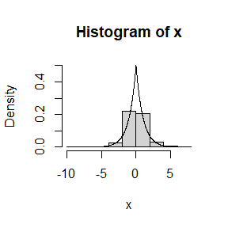

```r
n <- 1000
u <- runif(n)
x <- log(2*u)
x[u>=0.5] <- -log(2*(1-u[u>=0.5]))
hist(x, prob = TRUE, ylim = c(0,0.5)) #density histogram of sample
y <- seq(-8, 8, .01)
lines(y, 0.5*exp(-abs(y))) #density curve f(x)
```

## Question 3

Write a function to generate a random sample of size n from the Beta(a, b) distribution by the acceptance-rejection method. Generate a random sample of size 1000 from the Beta(3,2) distribution. Graph the histogram of the sample with the theoretical Beta(3,2) density superimposed.

### Answer

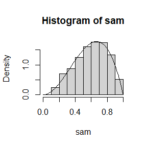

```r
general.acc.rej <- function(size, xs, df, dgen, rgen, c){
  acc.rej <- function(size, df, rgen, dgen, c){
    ct = 1
    n = 1
    res = numeric(size)
    while(n <= size){
      y = rgen(1)
      u = runif(1)
      if (u < df(y)/dgen(y)/c){
        res[n] = y
        n = n + 1
      }
      ct = ct + 1
    }
    return(res)
  }


  sam = acc.rej(size = size, df = df, rgen = rgen, dgen = dgen, c)
  return(sam)
}

myBeta <- function(size, a, b){
  rgen <- function(size) runif(size, min = u.min, max = u.max)
  dgen <- function(x) dunif(x, min = u.min, max = u.max)
  df <- function (x) dbeta(x = x, shape1 = a, shape2 = b)

  xs = seq(0, 1, 0.01)
  u.max = max(xs)
  u.min = min(xs)
  y.max = max(df(xs))
  c = y.max/(u.max - u.min)

  sam <- general.acc.rej (size = size, xs = xs, df = df, dgen = dgen, rgen = rgen, c = c)
  hist(sam, probability = TRUE)
  lines(xs, df(xs))
}

a = 3
b = 2
size = 1000

myBeta(size = size, a = a, b = b)
```

## Question 4

The rescaled Epanechnikov kernel is a symmetric density function
$$\begin{aligned}f_e(x)=\frac{3}{4}(1-x^2),\quad|x|\le1.\end{aligned}$$
Devroye and Gyorfi give the following algorithm for simulation from this distribution. Generate iid $U_1$, $U_2$, $U_3$ ∼ Uniform(−1, 1). If $|U_3| \ge|U_2|$ and $|U_3|\ge|U_1|$, deliver $U_2$; otherwise deliver $U_3$. Write a function to generate random variates from $f_e$, and construct the histogram density estimate of a large simulated random sample.

### Answer

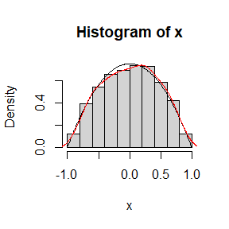

```r
re <- function(n){
  u1 <- runif(n, min = -1)
  u2 <- runif(n, min = -1)
  u3 <- runif(n, min = -1)
  x <- u3
  i <- (abs(u3)>=abs(u2)) & (abs(u3)>=abs(u1))
  x[i] <- u2[i]
  return(x)
}

x <- re(5000)
hist(x, prob = TRUE) #density histogram of sample
y <- seq(-1, 1, .01)
lines(y, 0.75*(1-y^2))
lines(density(x,bw = 0.1), col = 'red')
```

## Question 5

Prove that the algorithm given in **Question 4** generates variates from the density $f_e$.

### Answer

# Homework-2023.09.25

## Question 1

- Proof that what value $\rho=\frac{l}{d}$ should take to minimize the asymptotic variance of $\hat \pi$? (m ∼ B(n, p),using δ method)
- Take three different values of ρ (0 ≤ ρ ≤ 1, including $\rho_\min$) and use Monte Carlo simulation to verify your answer. (n = 106, Number of repeated simulations K = 100)

### Answer

Note that $\hat\theta=\frac{m}{n\rho}$ is an unbiased estimator of $\frac{2}{\pi}$ and $p=\frac{2\rho}{\pi}$, then

$$Var(\hat\theta)=\frac{Var(m)}{n^2\rho^2}=\frac{p(1-p)}{n\rho^2}
=\frac{2 (\pi-2\rho)}{n\pi^2\rho}.$$

It is easy to show that the minimum located at $\rho=1$($0<\rho\le1$).

```r
K = 100
n = 1e6
rho_test = c(0.3,0.6,1)
set.seed(111)
Est <- function(n, rho) {
  theta = runif(n, 0, pi/2)
  x = runif(n, 0, 1/2)
  # cross is a vector of true/false. Take the mean to find a proportion
  cross = x <= rho/2 * sin(theta)
  return(mean(cross))
}

for (rho in rho_test){
  E = c()
  for (k in 1:K){
    E[k] = 2*rho/Est(n, rho)
  }
  print(paste("rho =",rho,"Var =",var(E)))
}
```

```
## [1] "rho = 0.3 Var = 4.93605090405857e-05"
## [1] "rho = 0.6 Var = 1.63953441231448e-05"
## [1] "rho = 1 Var = 6.2825368451272e-06"
```

## Question 2

In Example 5.7 the control variate approach was illustrated for Monte Carlo integration of
$$\theta=\int_0^1e^xdx$$
Now consider the antithetic variate approach. Compute $Cov(e^U,e^{1-U})$ and $Var(e^U+e^{1-U})$, where $U\sim\text{Uniform}(0,1)$. What is the percent reduction in variance of $\hat{\theta}$ that can be achieved using antithetic variates (compared with simple MC)?

### Answer

$Cov(e^U,e^{1-U})=3e-e^2-1\doteq-0.2342106$

$Var(e^U+e^{1-U})=2Var(e^U)+2Cov(e^U,e^{1-U})={e^2-1}-2(e-1)^2+2(3e-e^2-1)=-3e^2+10e-5$

$$\begin{aligned}
nVar(\hat{\theta}_{c^*})&=Var(e^U)-\frac{[Cov(e^U,e^{1-U})]^2}{Var(e^{1-U})}\\
&\doteq0.2420356-(-0.2342106)^2/0.2420356\\
&=0.01539702
\end{aligned}$$

Then $100(1-0.01539702/0.2420356) = 93.63853\%$.

## Question 3

Refer to Exercise 5.6. Use a Monte Carlo simulation to estimate $\theta$ by the antithetic variate approach and by the simple Monte Carlo method. Compute an empirical estimate of the percent reduction in variance using the antithetic variate. Compare the result with the theoretical value from Exercise 5.6.

### Answer

```r
set.seed(111)
n = 1e5
e = exp(1)
a = -(3*e-e^2-1)/((e^2-1)/2-(e-1)^2)

U <- runif(n)
T1 <- exp(U) #simple MC
T2 <- exp(U) + a * (e^(1-U) - (e-1)) #controlled
c(mean(T1), mean(T2), exp(1)-1)
```

```
## [1] 1.717580 1.718617 1.718282
```

```r
c(sd(T1)/sqrt(n), sd(T2)/sqrt(n))
```

```
## [1] 0.0015572196 0.0003920023
```

# Homework-2023.10.09

## Question 1

Prove that if $g$ is a continuous function on $(a_0,a_k)$, then $Var(\hat{\theta}^{S})/Var(\hat{\theta}^{M})\to 0$ as $a_i-a_{i-1}\to 0$ for all $i=1,\dots,k$.

### Answer

We only need to prove $Var(\hat{\theta}^S)/Var(\hat{\theta}_I)\to0$
$$\begin{align}
Var(\theta_I)&=\frac{1}{k}\sum_{i=1}^{k}\left [
\sigma_i^2+\theta_i^2- \frac{1}{k^2}(\sum_{j=1}^{k} \theta_j )^2 \right
] \\
&= \mathbb{E}\left [ g(U)^2 \right ] -\frac{1}{k^2}(\sum_{j=1}^{k}
\theta_j )^2\\
&=Var(g(U))
\end{align}$$
$$\begin{align}
\frac{Var(\hat{\theta}^S )}{Var(\theta_I)}
&=\frac{\frac1{Mk}\sum_{i=1}^k\sigma_i^2}
{\frac{1}{M}Var(g(U))} \\
&=\frac{k\mathbb{E}\left [ g(U)^2 \right ]-\sum\theta_i^2}
{Var(g(U))}\\
\end{align}$$
Note $\sum a_i^2\le k\mathbb{E}\left [ g(U)^2 \right ]\le\sum b_i^2$ and $b_i-a_i\to0$, then

$$\sum(a_i^2-\theta_i^2)\le k\mathbb{E}\left [ g(U)^2 \right
]-\sum\theta_i^2\le\sum(b_i^2-\theta_i^2).$$

Thus $k\mathbb{E}\left [ g(U)^2 \right ]-\sum\theta_i^2\to 0$.

## Question 2 (5.13)

Find two importance functions $f_1$ and $f_2$ that are supported on $(1,\infty)$ and are ‘close’ to
$$\begin{align*}
g(x)=\frac{x^{2}}{\sqrt{2 \pi}} e^{-x^{2} / 2}, \quad x>1.
\end{align*}$$

### Answer

$f_2(x)=e^{1-x}$

I think $f_2$ is better, because it corresponds to the most nearly constant ratio $g(x)/f(x)$.

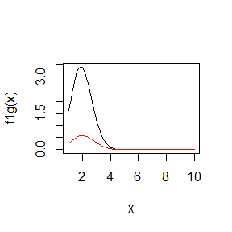

```r
g <- function(x){
  1/sqrt(2*pi)*x^2*exp(-x^2/2)
}

f1g <- function(x) g(x)/(1/pi/(1+x^2))
f2g <- function(x) g(x)/exp(1-x)

curve(f1g, from = 1, to = 10)
curve(f2g, from = 1, to = 10,add=T,col='red')
```

## Question 3 (5.14)

Which of your two importance functions should produce the smaller variance in estimating
$$\begin{align*}
\int_{1}^{\infty} \frac{x^{2}}{\sqrt{2 \pi}} e^{-x^{2} / 2} \text{d} x
\end{align*}$$
by importance sampling? Explain.

### Answer

```r
x <- rexp(1000,1) + 1
theta.hat <- mean(f2g(x))
theta.hat
```

```
## [1] 0.4089316
```

## Qustion 4 (5.15)

Obtain the stratified importance sampling estimate in Example 5.13 and compare it with the result of Example 5.10.

### Answer

```r
# M <- 1000
# k <- 10
# N <- 50
#
# T2 <- numeric(k)
# est <- matrix(0, N, 2)
#
# for (i in 1:N) {
#   x <- rexp(1000,1) + 1
#   est[i, 1] <- mean(f2g(x))
#   for(j in 1:k) T2[j]<-mean(g(runif(M/k,(j-1)/k,j/k)))
#   est[i, 2] <- mean(T2)
# }
# round(apply(est,2,mean),4)
```

## Question 5 (6.5)

Suppose a 95% symmetric t-interval is applied to estimate a mean, but the sample data are non-normal. Then the probability that the confidence interval covers the mean is not necessarily equal to 0.95. Use a Monte Carlo experiment to estimate the coverage probability of the t-interval for random samples of $\chi^2(2)$ data with sample size n = 20. Compare your t-interval results with the simulation results in Example 6.4. (The t-interval should be more robust to departures from normality than the interval for variance.)

### Answer

```r
m = 1e5
n = 20
set.seed(111)

reject <- NULL
for(i in 1:m){
  x <- rchisq(n,2)
  mu.hat = mean(x)
  sigma.hat = var(x)
  reject[i] <- (mu.hat<=2-sigma.hat*qt(0.9755,m-1)) || (mu.hat>=2+sigma.hat*qt(0.9755,m-1))
}
print(mean(reject))
```

```
## [1] 0.00103
```

## Question 6 (6.A)

Use Monte Carlo simulation to investigate whether the empirical Type I error rate of the t-test is approximately equal to the nominal significance level $\alpha$, when the sampled population is non-normal. The t-test is robust to mild departures from normality. Discuss the simulation results for the cases where the sampled population is (i) $\chi^2(1)$, (ii) Uniform$(0,2)$, and (iii) Exponential$(\text{rate} = 1)$. In each case, test $H_0 : \mu = \mu_0$ vs $H_1 : \mu \ne \mu_0$, where $\mu_0$ is the mean of $\chi^2(1)$, Uniform$(0,2)$, and Exponential$(1)$, respectively.

### Answer

```r
m = 1e5
n = 10
set.seed(111)

# chi(1)
reject <- NULL
for(i in 1:m){
  x <- rchisq(n,1)
  mu.hat = mean(x)
  sigma.hat = var(x)
  reject[i] <- (mu.hat<=1-sigma.hat*qt(0.9755,m-1)) || (mu.hat>=1+sigma.hat*qt(0.9755,m-1))
}
print(mean(reject))
```

```
## [1] 0.08118
```

```r
# U(0,2)
for(i in 1:m){
  x <- runif(n,0,2)
  mu.hat = mean(x)
  sigma.hat = var(x)
  reject[i] <- (mu.hat<=1-sigma.hat*qt(0.9755,m-1)) || (mu.hat>=1+sigma.hat*qt(0.9755,m-1))
}
print(mean(reject))
```

```
## [1] 0.03056
```

```r
# Exp(1)
for(i in 1:m){
  x <- rexp(n)
  mu.hat = mean(x)
  sigma.hat = var(x)
  reject[i] <- (mu.hat<=1-sigma.hat*qt(0.9755,m-1)) || (mu.hat>=1+sigma.hat*qt(0.9755,m-1))
}
print(mean(reject))
```

```
## [1] 0.0601
```